# Промышленность: обработка стали

# Содержание

## Условия задачи

Чтобы оптимизировать производственные расходы, металлургический комбинат ООО «Так закаляем сталь» решил уменьшить потребление электроэнергии на этапе обработки стали. Вам предстоит построить модель, которая предскажет температуру стали.

### Описание этапа обработки

Сталь обрабатывают в металлическом ковше вместимостью около 100 тонн. Чтобы ковш выдерживал высокие температуры, изнутри его облицовывают огнеупорным кирпичом. Расплавленную сталь заливают в ковш и подогревают до нужной температуры графитовыми электродами. Они установлены в крышке ковша.

Из сплава выводится сера (десульфурация), добавлением примесей корректируется химический состав и отбираются пробы. Сталь легируют — изменяют её состав — подавая куски сплава из бункера для сыпучих материалов или проволоку через специальный трайб-аппарат (англ. tribe, «масса»).

Перед тем как первый раз ввести легирующие добавки, измеряют температуру стали и производят её химический анализ. Потом температуру на несколько минут повышают, добавляют легирующие материалы и продувают сплав инертным газом. Затем его перемешивают и снова проводят измерения. Такой цикл повторяется до достижения целевого химического состава и оптимальной температуры плавки.

Тогда расплавленная сталь отправляется на доводку металла или поступает в машину непрерывной разливки. Оттуда готовый продукт выходит в виде заготовок-слябов (англ. *slab*, «плита»).

### Описание данных

Данные состоят из файлов, полученных из разных источников:

- `data_arc_new.csv` — данные об электродах;
- `data_bulk_new.csv` — данные о подаче сыпучих материалов (объём);
- `data_bulk_time_new.csv` — данные о подаче сыпучих материалов (время);
- `data_gas_new.csv` — данные о продувке сплава газом;
- `data_temp_new.csv` — результаты измерения температуры;
- `data_wire_new.csv` — данные о проволочных материалах (объём);
- `data_wire_time_new.csv` — данные о проволочных материалах (время).

Во всех файлах столбец `key` содержит номер партии. В файлах может быть несколько строк с одинаковым значением `key`: они соответствуют разным итерациям обработки.

### План проекта

- Подготовка данных и исследовательский анализ
  - Загрузка и знакомство с данными
  - Проверка корректности данных и графический анализ распределения признаков
- Предобработка данных
  - Выбор и подготовка признаков, необходимых для ML моделей
  - Генерация новых признаков
  - Сведение признаков в единую структуру данных
  - Корреляционный анализ взаимозависимости признаков
  - Разделение данных на обучающую и тестовую выборки
  - Выделение целевого признака
  - Заполнение или удаление пробелов и выбросов в данных
  - Приведение и оптимизация типов данных
- Построение и обучение моделей машинного обучения
  - Обучение различных моделей с оценкой их качества кросс-валидацией, выбор лучшей
  - Проверка выбранной модели на тестовой выборке
- Формулирование итоговых выводов
  - Подготовка и описание результатов исследования
  - Выработка рекомендаций
  - Составление отчета заказчику

### Результаты:

Данные были описаны, проанализированы, очищены от аномалий и выбросов, выделены признаки, необходимые для обучения.

Для обучения были выбраны 4 регрессионные модели:

1. Константная baseline модель (DummyRegressor, sklearn), предсказывающая целевой признак по среднему значению;
2. Линейная регрессия (LinearRegressor, sklearn);
3. Случайный лес (RandomForest, sklearn);
4. Градиентный бустинг (LGBMRegressor, lightgbm)
- Проведено обучение моделей машинного обучения и протестирована выбранная модель на предмет достижения поставленной цели по качеству предсказания
- По результатам проведенного методом кросс-валидации обучения была отобрана регрессионная модель, показавшая лучшие результаты.

Загрузка библиотек:

```python
import pandas as pd
import numpy as np
import matplotlib.pyplot as plt
import matplotlib.gridspec as gridspec
import seaborn as sns

from scipy import stats
from sklearn.model_selection import cross_val_score, GridSearchCV, RandomizedSearchCV, train_test_split
from sklearn.metrics import mean_absolute_error
from sklearn.preprocessing import StandardScaler, PolynomialFeatures, SplineTransformer
from sklearn.pipeline import Pipeline

from sklearn.dummy import DummyRegressor
from sklearn.ensemble import RandomForestRegressor, IsolationForest
from sklearn.linear_model import LinearRegression
from lightgbm import LGBMRegressor, plot_importance
```

Определение глобальных переменных:

```python
units = dict.fromkeys(['key', 'bulk_1', 'bulk_2', 'bulk_3', 'bulk_4', 'bulk_5', 'bulk_6',
                       'bulk_7', 'bulk_8', 'bulk_9', 'bulk_10', 'bulk_11', 'bulk_12',
                       'bulk_13', 'bulk_14', 'bulk_15', 'wire_1', 'wire_2', 'wire_3',
                       'wire_4', 'wire_5', 'wire_6', 'wire_7', 'wire_8', 'wire_9', 'gas_vol'], 'Объем')

units.update(dict.fromkeys(['heating_rounds'], 'кол.'))

units.update(dict.fromkeys(['heating_time',
                            'mean_heating_time',
                            'total_measure_period',
                            'total_heating_time',
                            'heating_period'], 'Секунды'))

units.update(dict.fromkeys(['active_power',
                            'reactive_power',
                            'mean_active_power',
                            'mean_reactive_power',
                            'total_active_power',
                            'total_reactive_power',
                            'full_power'], 'Мощность'))

units.update(dict.fromkeys(['work',
                            'total_work'], 'МДж.'))

units.update(dict.fromkeys(['temp',
                            'first_temp',
                            'last_temp'], 'Градусы'))

units
```

```
{'key': 'Объем',
 'bulk_1': 'Объем',
 'bulk_2': 'Объем',
 'bulk_3': 'Объем',
 'bulk_4': 'Объем',
 'bulk_5': 'Объем',
 'bulk_6': 'Объем',
 'bulk_7': 'Объем',
 'bulk_8': 'Объем',
 'bulk_9': 'Объем',
 'bulk_10': 'Объем',
 'bulk_11': 'Объем',
 'bulk_12': 'Объем',
 'bulk_13': 'Объем',
 'bulk_14': 'Объем',
 'bulk_15': 'Объем',
 'wire_1': 'Объем',
 'wire_2': 'Объем',
 'wire_3': 'Объем',
 'wire_4': 'Объем',
 'wire_5': 'Объем',
 'wire_6': 'Объем',
 'wire_7': 'Объем',
 'wire_8': 'Объем',
 'wire_9': 'Объем',
 'gas_vol': 'Объем',
 'heating_rounds': 'кол.',
 'heating_time': 'Секунды',
 'mean_heating_time': 'Секунды',
 'total_measure_period': 'Секунды',
 'total_heating_time': 'Секунды',
 'heating_period': 'Секунды',
 'active_power': 'Мощность',
 'reactive_power': 'Мощность',
 'mean_active_power': 'Мощность',
 'mean_reactive_power': 'Мощность',
 'total_active_power': 'Мощность',
 'total_reactive_power': 'Мощность',
 'full_power': 'Мощность',
 'work': 'МДж.',
 'total_work': 'МДж.',
 'temp': 'Градусы',
 'first_temp': 'Градусы',
 'last_temp': 'Градусы'}
```

```python
figsize = (12, 6)
random_state = 80523
test_size = 0.25
```

Загрузка наборов данных:

```python
dataset_local_path = '/home/panther/Documents/Deep Learning/datasets/final_steel/'
dataset_web_path = 'https://code.s3.yandex.net/datasets/'

file_names = ['data_arc_new.csv', 'data_bulk_new.csv', 'data_bulk_time_new.csv', 'data_gas_new.csv',
             'data_temp_new.csv', 'data_wire_new.csv', 'data_wire_time_new.csv']

def load_dataset(path):
    dfs = []
    for file_name in file_names:
        dfs.append(pd.read_csv(path + file_name))
    return dfs

try:
    arc, bulk, bulk_time, gas, temp, wire, wire_time = load_dataset(dataset_local_path)
    print('Загрузка данных из локального каталога прошла успешно')
except:
    print('Произошла ошибка с загрузкой файлов. Проверьте корректность имён и путей')
    print('Начата загрузка из веб-архива. Убедитесь, что интернет подключен')
    try:
        arc, bulk, bulk_time, gas, temp, wire, wire_time = load_dataset(dataset_web_path)
        print('\tЗагрузка данных из веб-архива прошла успешно')
    except:
        print('\tЗагрузить файлы из веб-архива НЕ УДАЛОСЬ')
```

```
Загрузка данных из локального каталога прошла успешно
```

## Знакомство с данными и исследовательский анализ

Проверка на явные дубликаты строк в данных:

```python
for df in arc, bulk, bulk_time, gas, temp, wire, wire_time:
    print(df.columns)
```

```
Index(['key', 'Начало нагрева дугой', 'Конец нагрева дугой',
       'Активная мощность', 'Реактивная мощность'],
      dtype='object')
Index(['key', 'Bulk 1', 'Bulk 2', 'Bulk 3', 'Bulk 4', 'Bulk 5', 'Bulk 6',
       'Bulk 7', 'Bulk 8', 'Bulk 9', 'Bulk 10', 'Bulk 11', 'Bulk 12',
       'Bulk 13', 'Bulk 14', 'Bulk 15'],
      dtype='object')
Index(['key', 'Bulk 1', 'Bulk 2', 'Bulk 3', 'Bulk 4', 'Bulk 5', 'Bulk 6',
       'Bulk 7', 'Bulk 8', 'Bulk 9', 'Bulk 10', 'Bulk 11', 'Bulk 12',
       'Bulk 13', 'Bulk 14', 'Bulk 15'],
      dtype='object')
Index(['key', 'Газ 1'], dtype='object')
Index(['key', 'Время замера', 'Температура'], dtype='object')
Index(['key', 'Wire 1', 'Wire 2', 'Wire 3', 'Wire 4', 'Wire 5', 'Wire 6',
       'Wire 7', 'Wire 8', 'Wire 9'],
      dtype='object')
Index(['key', 'Wire 1', 'Wire 2', 'Wire 3', 'Wire 4', 'Wire 5', 'Wire 6',
       'Wire 7', 'Wire 8', 'Wire 9'],
      dtype='object')
```

```python
arc.columns = ['key', 'heating_start', 'heating_stop', 'active_power', 'reactive_power']
gas.columns = ['key', 'gas_vol']
bulk.columns = bulk.columns.str.lower().str.replace(' ', '_')
bulk_time.columns = bulk_time.columns.str.lower().str.replace(' ', '_')
temp.columns = ['key', 'measure_time', 'temp']
wire.columns = wire.columns.str.lower().str.replace(' ', '_')
wire_time.columns = wire_time.columns.str.lower().str.replace(' ', '_')
```

```python
for df in arc, bulk, bulk_time, gas, temp, wire, wire_time:
    print(df.duplicated().sum())
```

```
0
0
0
0
0
0
0
```

Дубликатов не выявлено.

Функции построения графиков распределения:

```python
def plot_hist(ax=None, series=None, bins=50, density=True):
    mean = series.mean(); mode = series.mode()[0]
    ax = ax or plt.gca()

    hist = sns.histplot(series, bins=bins, kde=True, linewidth=0, ax=ax)
    heights = [patch.get_height() for patch in ax.patches]; max_height = max(heights)
    ax.axvline(mean, color='black', ls='--')
    ax.axvline(mode, color='blue', ls='--')
    ax.text(mean+mean/50, max_height/3, f'$\mu_e\ =\ {mean:.2f}\ $')
    ax.text(mode+mode/50, max_height/4, f'$\mu_o\ =\ {mode:.2f}\ $', color='blue')
    ax.set_xlabel(f'{units[series.name]}'); ax.set_ylabel('Частота');
    ax.set_title(f'Распределение параметра \n{series.name}')

    return hist

def plot_hist_and_box(series, bins=50, density=True):
    _, (ax0, ax1) = plt.subplots(1, 2, gridspec_kw={'width_ratios': [4, 1]}, figsize=figsize)
    plot_hist(ax0, series, bins=bins, density=density)
    ax1.boxplot(series)
    ax1.set_title(f'Диаграма размаха параметра \n{series.name}');
    ax1.set_xlabel(series.name); ax1.set_ylabel(units[series.name])


def plot_hists_and_boxes(df, hist_grid_shape, box_grid_shape, density=True, bins=50):
    fig = plt.figure(figsize=(figsize[0], figsize[1]*hist_grid_shape[0]/2+figsize[1]*box_grid_shape[0]))
    outer = gridspec.GridSpec(2, 1, right=1.5, top=1.1, height_ratios=[hist_grid_shape[0], box_grid_shape[0]])
    hist_inner = gridspec.GridSpecFromSubplotSpec(*hist_grid_shape, subplot_spec=outer[0], hspace=0.4)
    box_inner = gridspec.GridSpecFromSubplotSpec(*box_grid_shape, subplot_spec=outer[1], wspace=0.5)

    for i, col_name in enumerate(df.columns):
        ax0 = plt.Subplot(fig, hist_inner[i])
        ax1 = plt.Subplot(fig, box_inner[i])
        plot_hist(ax0, df[col_name], density=density, bins=bins)
        ax1.boxplot(df[col_name].dropna())
        ax1.set_title(f'{col_name}')
        ax1.set_ylabel(units[col_name])
        fig.add_subplot(ax0)
        fig.add_subplot(ax1)
```

### Анализ `data_arc_new.csv`

#### Знакомство с данными

```python
arc.head()
```

|  | key | heating_start | heating_stop | active_power | reactive_power |
| --- | --- | --- | --- | --- | --- |
| 0 | 1 | 2019-05-03 11:02:14 | 2019-05-03 11:06:02 | 0.305130 | 0.211253 |
| 1 | 1 | 2019-05-03 11:07:28 | 2019-05-03 11:10:33 | 0.765658 | 0.477438 |
| 2 | 1 | 2019-05-03 11:11:44 | 2019-05-03 11:14:36 | 0.580313 | 0.430460 |
| 3 | 1 | 2019-05-03 11:18:14 | 2019-05-03 11:24:19 | 0.518496 | 0.379979 |
| 4 | 1 | 2019-05-03 11:26:09 | 2019-05-03 11:28:37 | 0.867133 | 0.643691 |

```python
arc.info()
```

```
<class 'pandas.core.frame.DataFrame'>
RangeIndex: 14876 entries, 0 to 14875
Data columns (total 5 columns):
 #   Column          Non-Null Count  Dtype
---  ------          --------------  -----
 0   key             14876 non-null  int64
 1   heating_start   14876 non-null  object
 2   heating_stop    14876 non-null  object
 3   active_power    14876 non-null  float64
 4   reactive_power  14876 non-null  float64
dtypes: float64(2), int64(1), object(2)
memory usage: 581.2+ KB
```

Пропусков нет. Неверно определены типы данных для дат, корректирую:

```python
arc[['heating_start', 'heating_stop']] = \
pd.to_datetime(arc[['heating_start', 'heating_stop']].stack()).unstack()
```

```python
arc['heating_stop'].max() - arc['heating_start'].min()
```

```
Timedelta('126 days 06:24:01')
```

Данные за 127 дней

```python
arc.describe()
```

|  | key | heating_start | heating_stop | active_power | reactive_power |
| --- | --- | --- | --- | --- | --- |
| count | 14876.000000 | 14876 | 14876 | 14876.000000 | 14876.000000 |
| mean | 1615.220422 | 2019-07-05 12:25:51.921081088 | 2019-07-05 12:28:43.592027392 | 0.662752 | 0.438986 |
| min | 1.000000 | 2019-05-03 11:02:14 | 2019-05-03 11:06:02 | 0.223120 | -715.479924 |
| 25% | 806.000000 | 2019-06-03 23:18:23.249999872 | 2019-06-03 23:21:35 | 0.467115 | 0.337175 |
| 50% | 1617.000000 | 2019-07-03 01:31:26.500000 | 2019-07-03 01:35:13 | 0.599587 | 0.441639 |
| 75% | 2429.000000 | 2019-08-07 22:52:20.750000128 | 2019-08-07 22:56:47 | 0.830070 | 0.608201 |
| max | 3241.000000 | 2019-09-06 17:24:54 | 2019-09-06 17:26:15 | 1.463773 | 1.270284 |
| std | 934.571502 | NaN | NaN | 0.258885 | 5.873485 |

Аномальный минимум значения признака `Реактивная мощность`. Реактивная мощность бывает отрицательной при создании системой реактивной мощности, но так как это невозможно при плавке (при этом мощность поглощается), то скорее всего это ошибка в данных.

Попробую восстановить некорректное значение:

```python
arc.sort_values(by='reactive_power').head()
```

|  | key | heating_start | heating_stop | active_power | reactive_power |
| --- | --- | --- | --- | --- | --- |
| 9780 | 2116 | 2019-07-28 02:22:08 | 2019-07-28 02:23:57 | 0.705344 | -715.479924 |
| 709 | 152 | 2019-05-09 11:26:58 | 2019-05-09 11:29:41 | 0.228852 | 0.153777 |
| 3290 | 711 | 2019-05-31 07:16:01 | 2019-05-31 07:20:05 | 0.242989 | 0.153921 |
| 11794 | 2567 | 2019-08-13 05:51:16 | 2019-08-13 05:52:22 | 0.288314 | 0.155221 |
| 6130 | 1336 | 2019-06-22 15:46:26 | 2019-06-22 15:47:50 | 0.244191 | 0.156525 |

Видно, что есть всего одно такое значение.

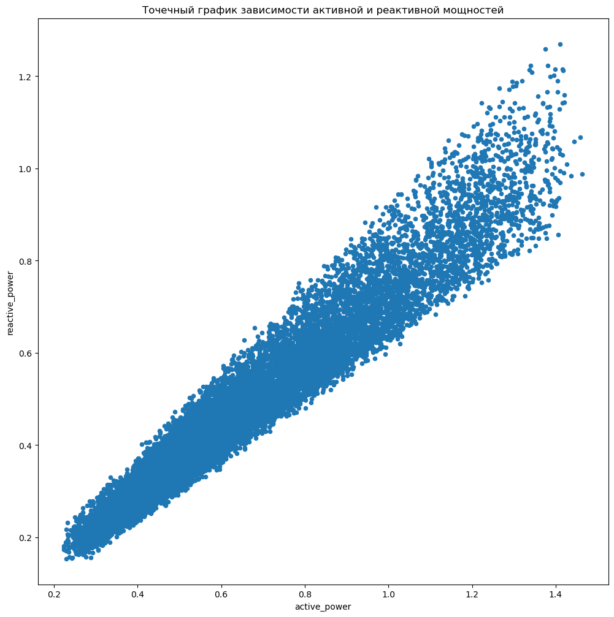

```python
arc[['active_power', 'reactive_power']].drop(9780).plot.scatter(x='active_power',
                                                     y ='reactive_power',
                                                     figsize=(figsize[0], figsize[0]))
plt.title('Точечный график зависимости активной и реактивной мощностей');
```

Видна линейная зависимость между значениями активной и реактивной мощностей.

```python
arc.loc[9780, 'active_power']
```

```
0.705344
```

```python
lr_arc_restore = LinearRegression()
lr_arc_restore.fit(arc['active_power'].to_numpy().reshape(-1, 1), arc['reactive_power'])
restored_rp =  lr_arc_restore.predict([[arc.loc[9780, 'active_power']]])
restored_rp
```

```
array([0.46910049])
```

```python
arc.loc[9780, 'reactive_power'] = restored_rp
```

```python
arc['reactive_power'].min()
```

```
0.153777
```